# ggplot2 Use Cases

J. R. Minter

Started: 2016-01-20, Last modified: 2019-04-29

Back to Index

This is a work in progress. it also requires **ggplot2 version 3.0**.

# 1 Capture thoughts for enhancements at the top…

## 1.1 Ideas to remember

Start with the [reference](https://ggplot2.tidyverse.org/reference/) documentation…

### 1.1.1 Dates are a real pain…

[This](https://stackoverflow.com/questions/30015926/difficulty-annotating-plot-when-x-axis-values-are-dates) helped.

### 1.1.2 Colors…

[changing colors](http://www.sthda.com/english/wiki/ggplot2-colors-how-to-change-colors-automatically-and-manually)

### 1.1.3 Plotting multiple series

[sixhat.net](https://www.sixhat.net/how-to-plot-multpile-data-series-with-ggplot.html) was helpful.

### 1.1.4 Legends

These can be fun. [Stackoverflow](https://stackoverflow.com/questions/17148679/construct-a-manual-legend-for-a-complicated-plot) helped…

## 1.2 Margins

From [RLadies twitter](https://twitter.com/WeAreRLadies/status/1123109094422921216):

Margins can be specified logically (all yes or all no) or for specific variables as (character variable names)

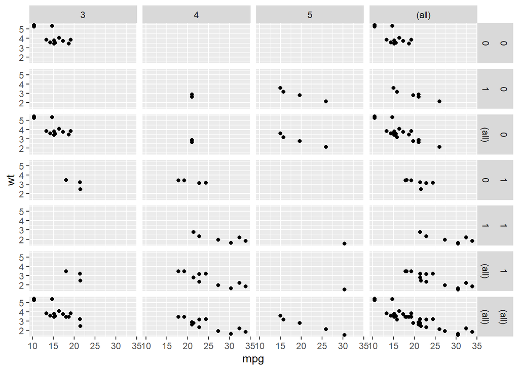

```r
library(ggplot2)
mg <- ggplot(mtcars, aes(x=mpg, y=wt)) +
      geom_point() +
      facet_grid(vs + am ~ gear, margins = TRUE) +
      NULL

mg
```

## 1.3 Add a branding caption

Insert this in the code:

```
labs(caption = 'jrminter@gmail.com / @jrminter') +
```

Credit: [Michael Toth](https://michaeltoth.me/you-need-to-start-branding-your-graphs-heres-how-with-ggplot.html)

## 1.4 Build up plot in slides

See [Garrick Aden-Buie’s blog](https://www.garrickadenbuie.com/blog/2018/08/16/decouple-code-and-output-in-xaringan-slides/).

## 1.5 Limits and clipping

This was explained on [stackoverflow](https://stackoverflow.com/questions/25685185/limit-ggplot2-axes-without-removing-data-outside-limits-zoom).

Start with a simple plot…

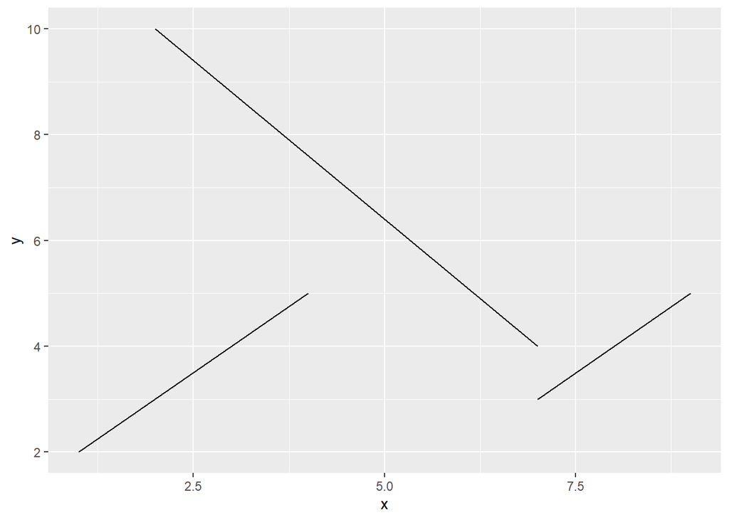

```r
library(ggplot2)
d <-  data.frame(x=c(1,4,7,2,9,7),
                 y=c(2,5,4,10,5,3),
                 grp=c('a','a','b','b','c','c'))

plt <- ggplot(d, aes(x, y, group=grp)) + geom_line()
print(plt)
```

Note how this next one is clipped

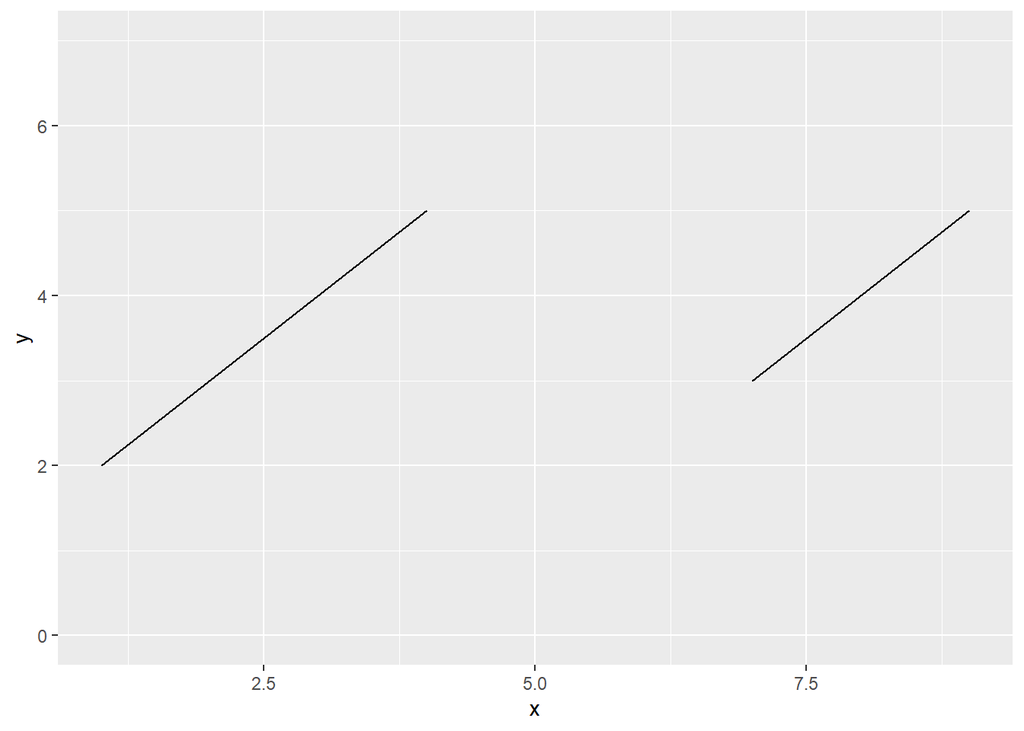

```r
plt2 <- ggplot(d, aes(x, y, group=grp)) +
        geom_line() +
        scale_y_continuous(limits=c(0,7))
print(plt2)
```

As is this one…

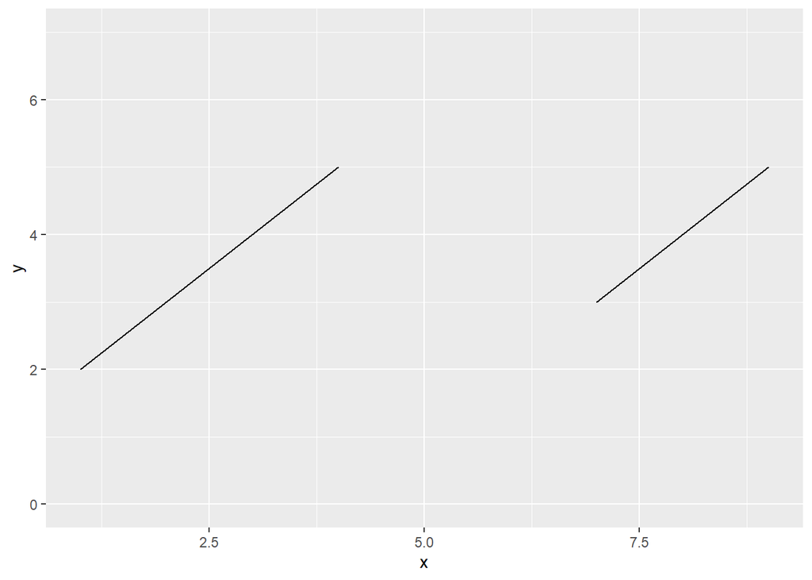

```r
plt3 <- ggplot(d, aes(x, y, group=grp)) +
        geom_line() + ylim(0,7)
print(plt3)
```

But using `coord_cartesian(ylim=c(0, 7))` fixes it…

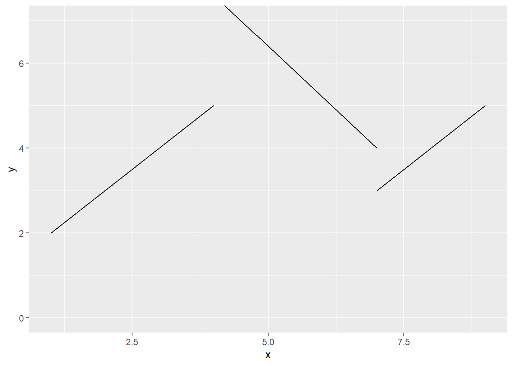

```r
plt4 <- ggplot(d, aes(x, y, group=grp)) +
        geom_line() +
        coord_cartesian(ylim=c(0, 7))
print(plt4)
```

## 1.6 Testing ggplot2 version 3

This just came out (2018-07-04). Here is a nice example from [johnmackintosh.com](https://www.johnmackintosh.com/2018-07-04-tidily-evaluated-ggplot2/)

```r
library(dplyr)
library(ggplot2)
library(tidyr)
library(tibble)

data <- list(fdeaths,mdeaths,ldeaths) # time series data. Needs prep
names(data)[1:3] <- c("fdeaths","mdeaths","ldeaths")
data <- as_tibble(data)
startdate <- as.Date('1974-1-1')
data$date <- seq.Date(startdate,by = 'month',length.out = 72)
newdata <- tidyr::gather(data, key = key, value = value,-date)
newdata$value <- as.numeric(newdata$value)

# create generic function
gtest <- function(df,x,y, group) {
  x_quo <- enquo(x)
  y_quo <- enquo(y)
  group_quo <- enquo(group)
  p <- ggplot(df,aes(x = !!x_quo, y = !!y_quo)) +   #bangin'
  geom_line(colour = "blue", group = 1) +
  geom_point(colour = "blue") +
  facet_wrap(group_quo, ncol = 3) #look Ma, no need to bang bang here!
  p <- p + ggtitle(label = "Easy Tidy Eval in ggplot 3.0.0",
                   subtitle = "ggplot with tidy evaluation & facetting with no strings")
  p <- p + labs(x = NULL, y = NULL, caption = "") +
  theme_bw()
  p
}
```

Now test it

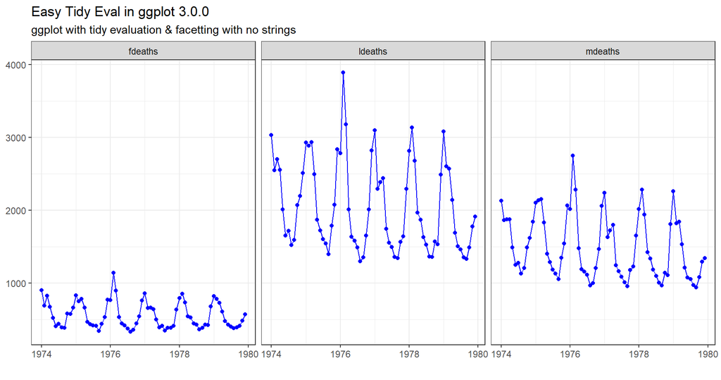

```r
gtest(newdata,date,value,key)
```

## 1.7 Make it easy to comment out parts

From [Wei Yang Tham](https://twitter.com/wytham88/status/1012085073368272903)

> One of my favorite ggplot2 tricks, which I learned on the `@R4DScommunity` Slack group: add `NULL` to the end of your ggplot chain so you can comment out a command without ending with a `+`.

His example had problems, so I made one based on [this](http://www.sthda.com/english/wiki/ggplot2-density-plot-quick-start-guide-r-software-and-data-visualization) example.

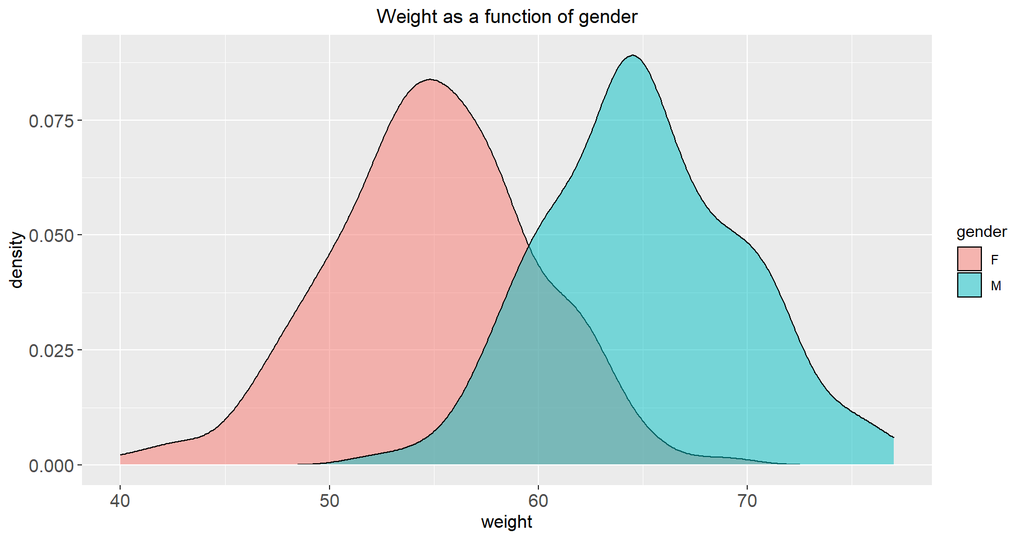

```r
library(ggplot2)
set.seed(42)
df <- data.frame(gender = factor(rep(c("F", "M"), each = 200)),
                 weight = round(c(rnorm(200, mean = 55, sd=5),
                                  rnorm(200, mean = 65, sd=5))))

plt <- ggplot(df, aes(x=weight, fill=gender)) +
       geom_density(alpha=0.5) +
       geom_hline(yintercept = 0, colour='white') +
       ggtitle("Weight as a function of gender") +
       theme(axis.text=element_text(size=12),
             axis.title=element_text(size=12),
             plot.title=element_text(hjust = 0.5)) +
       # geom_histogram() +
       NULL
print(plt)
```

## 1.8 Creating legends when aesthetics are constants

### 1.8.1 Introduction

In general, if you want to map an aesthetic to a variable and get a legend in `ggplot2` you do it inside `aes()`. If you want to set an aesthetic to a constant value, like making all the points purple, you do it outside aes().

However, there are situations where you might want to set an aesthetic for a layer to a constant but you also want a legend for that aesthetic. One common alternative is to put your dataset into a long format to take advantage of the strengths of `ggplot2`, but that isn’t an option for every situation. I’ll show another approach here.

### 1.8.2 The setup

A few situations where we might want legends without mapping an aesthetic to a variable are:

1. Adding a statistic like the mean as a line or symbol and wanting a legend to define it.
2. Adding separate layers for subsets of data or based on different datasets. This second situation is where reformatting your dataset is often most useful.
3. Adding lines based on different fitted models

I’ll focus on adding lines from different models. I’m going to be using the ubiquitous `mtcars` dataset because, well, it’s easy.

### 1.8.3 Making a plot with aesthetics as constant

I’ll start by loading the ggplot2 package.

```r
library(ggplot2) # v. 3.0.0
```

I’m going to make a plot of the relationship between `mpg` and `hp`, adding three fitted lines from three different linear regression models. I will use a linear, a quadratic, and a cubic model. I use `geom_smooth()` to make the fitted regression lines, and so add a separate `geom_smooth()` layer for each model.

I’m going to focus on the color aesthetic here, but this is relevant for other aesthetics, as well.

You’ll see I set a different color per fitted line. Since I’m setting these colors as constants this is done outside `aes()`.

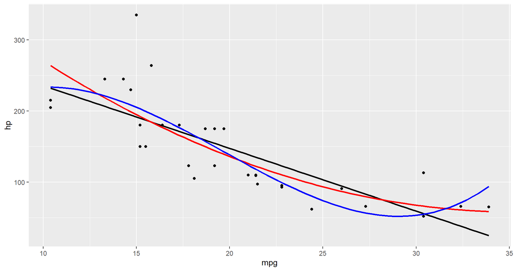

```r
ggplot(mtcars, aes(mpg, hp) ) +
  geom_point() +
  geom_smooth(method = "lm", se = FALSE, color = "black") +
  geom_smooth(method = "lm", formula = y ~ poly(x, 2), se = FALSE, color = "red") +
  geom_smooth(method = "lm", formula = y ~ poly(x, 3), se = FALSE, color = "blue")
```

### 1.8.4 Adding a legend

It would be nice to know which line came from which model, and adding a legend is one way to do that. The question is, how do we add a legend?

I think for many people it feels intuitive to add the appropriate `scale_*()` function to the plotting code in hopes of getting a legend. Along those lines I’ll add `scale_color_manual()` to my plot.

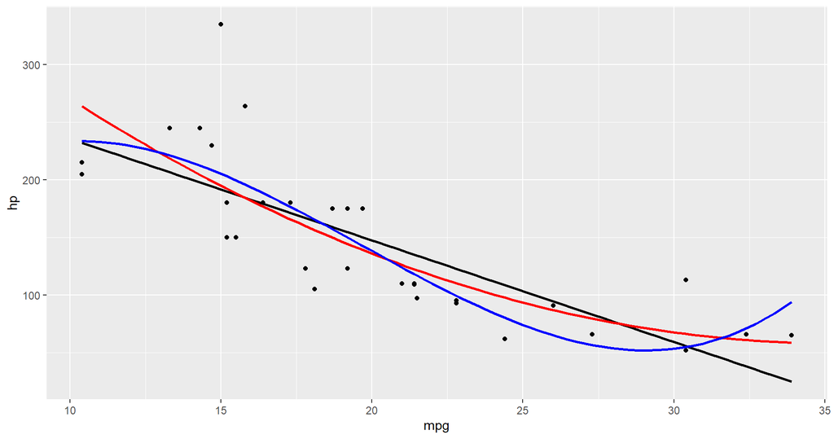

```r
ggplot(mtcars, aes(mpg, hp) ) +
  geom_point() +
  geom_smooth(method = "lm", se = FALSE, color = "black") +
  geom_smooth(method = "lm", formula = y ~ poly(x, 2), se = FALSE, color = "red") +
  geom_smooth(method = "lm", formula = y ~ poly(x, 3), se = FALSE, color = "blue") +
  scale_color_manual(values = c("black", "red", "blue") )
```

But nothing changes. Unfortunately, no matter how hard I throw `scale_color_manual()` at the plot, I won’t get a legend.

Why doesn’t this work?

From the description in the scale_manual documentation, the manual scale functions allow you to specify your own set of mappings from levels in the data to aesthetic values. You can change already created mappings but not construct them. In `ggplot2`, mappings are constructed by `aes()`. **Aesthetics therefore must be inside** `aes()` **to get a legend**.

### 1.8.5 Adding a legend by moving aesthetics into `aes()`

I’ll move color inside of `aes()` within each `geom_smooth()` layer to construct color mappings. This adds a legend to the plot.

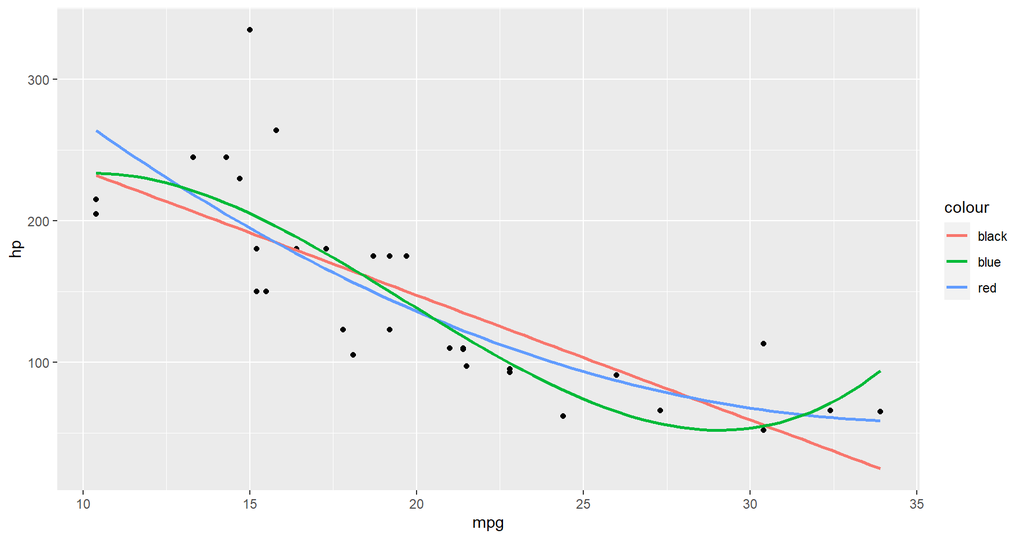

```r
ggplot(mtcars, aes(mpg, hp) ) +
  geom_point() +
  geom_smooth(method = "lm", se = FALSE, aes(color = "black") ) +
  geom_smooth(method = "lm", formula = y ~ poly(x, 2), se = FALSE, aes(color = "red") ) +
  geom_smooth(method = "lm", formula = y ~ poly(x, 3), se = FALSE, aes(color = "blue") )
```

A legend is now present, but the colors have changed. The values are no longer recognized as colors since `aes()` treats these as string constants. To get the desired colors we’ll need to turn to one of the `scale_color_*()` functions.

### 1.8.6 Using `scale_color_identity()` to recognize color strings

One way to force ggplot to recognize the color names when they are inside `aes()` is to use `scale_color_identity()`. To get a legend with an identity scale you must use `guide = "legend"`. (The default is `guide = "none"` for identity scales.)

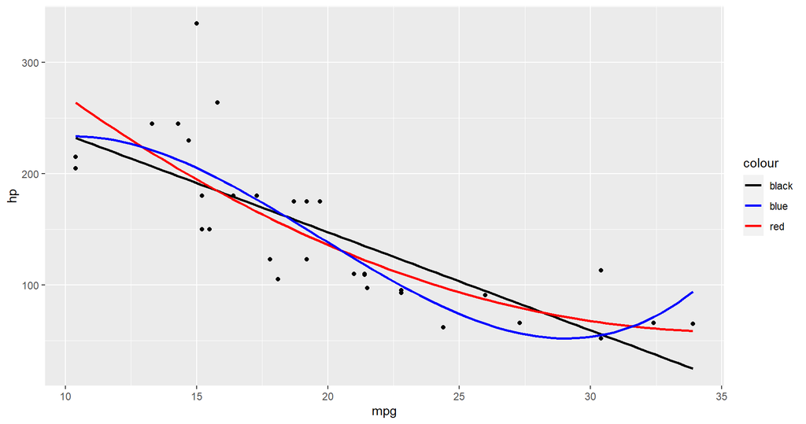

```r
ggplot(mtcars, aes(mpg, hp) ) +
  geom_point() +
  geom_smooth(method = "lm", se = FALSE, aes(color = "black") ) +
  geom_smooth(method = "lm", formula = y ~ poly(x, 2), se = FALSE, aes(color = "red") ) +
  geom_smooth(method = "lm", formula = y ~ poly(x, 3), se = FALSE, aes(color = "blue") ) +
  scale_color_identity(guide = "legend")
```

The colors are now correct but the legend still leaves a lot to be desired. The name of the legend isn’t useful, the order is alphabetical instead of by model complexity, and the labels are the color names instead of descriptive names that describe each model.

The legend name can be changed via name, the order can be changes via breaks and the labels can be changed via labels in `scale_color_identity()`. The order of the labels must be the same as the order of the breaks.

This all means the `scale_color_identity()` code has gotten relatively more complicated. I’ve found this to be pretty standard when mapping aesthetics to constants.

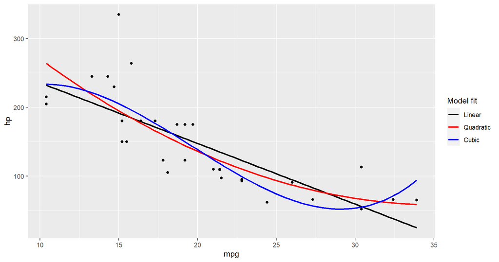

```r
ggplot(mtcars, aes(mpg, hp) ) +
  geom_point() +
  geom_smooth(method = "lm", se = FALSE, aes(color = "black") ) +
  geom_smooth(method = "lm", formula = y ~ poly(x, 2), se = FALSE, aes(color = "red") ) +
  geom_smooth(method = "lm", formula = y ~ poly(x, 3), se = FALSE, aes(color = "blue") ) +
  scale_color_identity(name = "Model fit",
                       breaks = c("black", "red", "blue"),
                       labels = c("Linear", "Quadratic", "Cubic"),
                       guide = "legend")
```

### 1.8.7 Descriptive strings and `scale_color_manual()`

An alternative (but not necessarily simpler) approach is to use informative string names instead of the color names within `aes()`. Then we can use `scale_color_manual()` to get the legend cleaned up.

Here is the plot using descriptive names that describe each model instead of the color names.

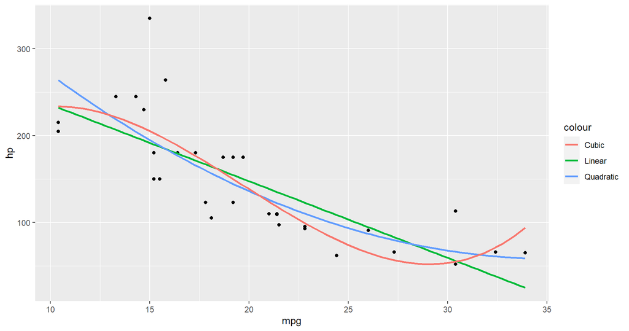

```r
ggplot(mtcars, aes(mpg, hp) ) +
  geom_point() +
  geom_smooth(method = "lm", se = FALSE, aes(color = "Linear") ) +
  geom_smooth(method = "lm", formula = y ~ poly(x, 2), se = FALSE, aes(color = "Quadratic") ) +
  geom_smooth(method = "lm", formula = y ~ poly(x, 3), se = FALSE, aes(color = "Cubic") )
```

This has nicer labels, but the legend has other problems, similar to those in the above `scale_color_identity()` example. The legend name isn’t informative, the order is again alphabetical instead of by model complexity, and the colors still need to be changed if we really want black, red, and blue lines. This can all be addressed in `scale_color_manual()`.

For the first two issues I will again use name and breaks to get things named and in the desired order.

Colors are set via passing a vector of color names to the values argument in `scale_color_manual()`. Note the values argument is a **required aesthetic** in `scale_color_manual()`; if you don’t want to change the colors in the plot use `scale_color_discrete()`.

The vector of colors needs to **either be in the same order as the** **breaks** or **given as a named vector**. The latter is “safest” since it is invariant to changing the order of the legend, and I’ll use a named vector in my example code.

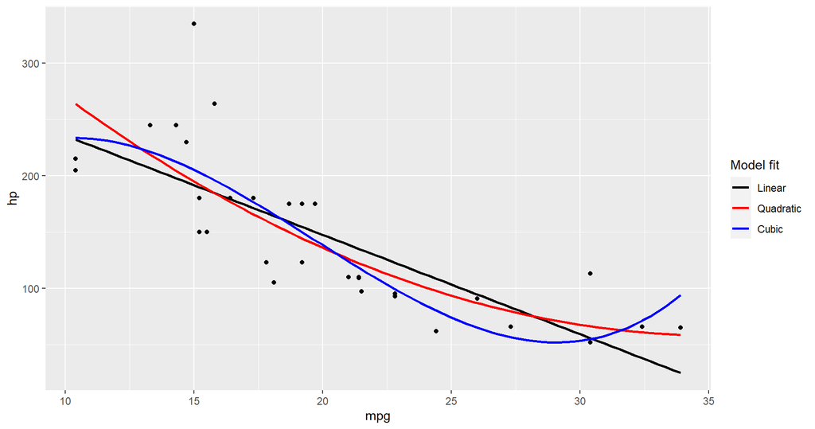

```r
ggplot(mtcars, aes(mpg, hp) ) +
  geom_point() +
  geom_smooth(method = "lm", se = FALSE, aes(color = "Linear") ) +
  geom_smooth(method = "lm", formula = y ~ poly(x, 2), se = FALSE, aes(color = "Quadratic") ) +
  geom_smooth(method = "lm", formula = y ~ poly(x, 3), se = FALSE, aes(color = "Cubic") ) +
  scale_color_manual(name = "Model fit",
                     breaks = c("Linear", "Quadratic", "Cubic"),
                     values = c("Cubic" = "blue", "Quadratic" = "red", "Linear" = "black") )
```

## 1.9 Designing conceptual plots

This [example](https://github.com/andrewheiss/supply-demand-ggplot) by Andrew Heiss is excellent!

## 1.10 Adding functions

This is a work in progress. Some resources for later

[R-Studio example](http://rstudio-pubs-static.s3.amazonaws.com/3365_9573f6d661b444499365fe1841ee65d3.html)

[t-redactyl.io](http://t-redactyl.io/blog/2016/03/creating-plots-in-r-using-ggplot2-part-9-function-plots.html)

# 2 Rationale for this document

I typically have spurts where I use R and ggplot2 (Wickham 2016) to analyze data and find myself saying, “I’ve done this before, but where is the code?” These exemplars should make it easy to get back up to speed quickly. As Karl Broman noted:

> Your closest collaborator is you six months ago and you don’t respond to email!

So this is for “future me” and anybody else who needs it. See also the **ggplotExamples** project in your private jrm-solutions repo.

Also note [this](https://martinsbioblogg.wordpress.com/2017/04/23/using-r-a-function-that-adds-multiple-ggplot2-layers/) recent helpful example.

Now get started

First, let’s load the packages we need.

```r
library(tidyverse)
library(latex2exp)
library(pander)
library(here)
```

**Note:** For pander options see [rapporter.github.io](http://rapporter.github.io/pander/#pander-options).

# 3 Plot time dependent data

This group of examples comes from [www.statworx.com](https://www.statworx.com/de/blog/customizing-time-and-date-scales-in-ggplot2/).

## 3.1 Base plot

We are using ggplot’s **economics** data set. Our base plot looks like this:

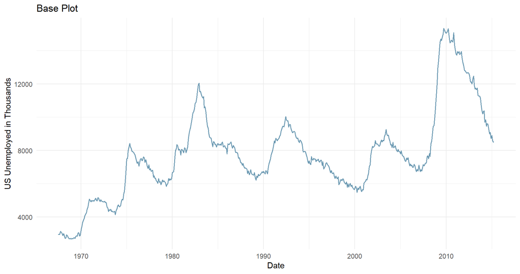

```r
library(ggplot2)

base_plot <- ggplot(data = economics) +
             geom_line(aes(x = date, y = unemploy),
                       color = "#09557f", alpha = 0.6, size = 0.6) +
             labs(x = "Date", y = "US Unemployed in Thousands",
             title = "Base Plot") +
             theme_minimal()
print(base_plot)
```

## 3.2 Scale types

As of now, `ggplot2` supports three date and time classes: `POSIXct`, `Date` and `hms`.

Depending on the class at hand, axis ticks and labels can be controlled by using `scale_*_date`, `scale_*_datetime` or `scale_*_time`, respectively. Depending on whether `scale_x_*` or not, it is `scale_y_*` to be used in a job. For the sake of simplicity, the examples only `scale_x_date` are used, but all are the same.

## 3.3 Minor Modification 1

Let’s start easy. With the argument limitsthe range of the displayed dates or time can be set. Two values of the correct date or time.

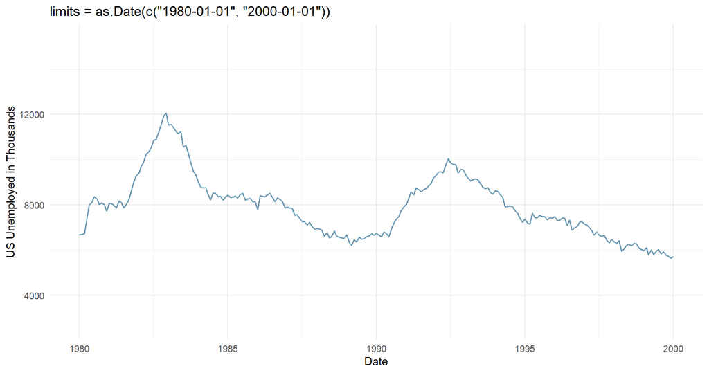

```r
plt_mod1 <- base_plot +
            scale_x_date(limits = as.Date(c("1980-01-01", "2000-01-01"))) +
            ggtitle("limits = as.Date(c(\"1980-01-01\", \"2000-01-01\"))")

print(plt_mod1)
```

The `expand`argument ensures there is some distance between the displayed data and the axes. The argument `expand`takes two numeric values, the first is the multiplicative expansion constant. The larger one of the two distances is employed in the plot, the multiplied constant is multiplied by the range of the displayed data. The resulting empty space is at the left and right end of the x-axis or the top and bottom of the y-axis.

The `position`argument defines where the labels are displayed: Either “left” or “right” from the y-axis or on the “top” or “bottom” from the x-axis.

## 3.4 Axis Ticks and Grid Lines

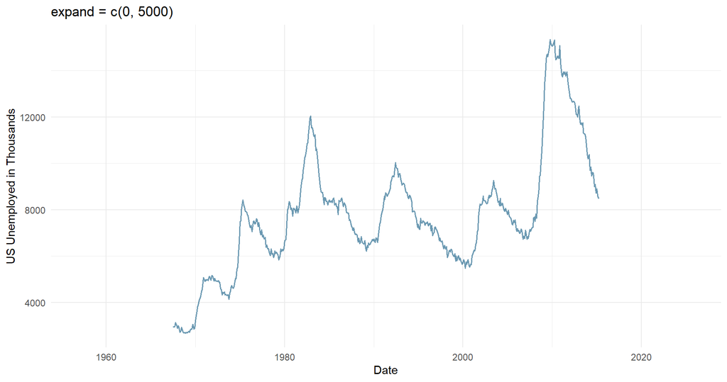

```r
plt_mod2 <- base_plot +
            scale_x_date(expand = c(0, 5000)) + #5000/365 = 13.69863 years
            ggtitle("expand = c(0, 5000)")

print(plt_mod2)
```

Furthermore and very conveniently, the format of the labels can be controlled by the following `date_labels`. Note how the example **sets the default table alignment…**

```r
fi <- here('ggplot2UseCases/dat/csv/date-time-codes.csv')
panderOptions('table.alignment.default','left')
df <- read.csv(fi)
pander(df)
```

| code | meaning |
| --- | --- |
| %S | second (00-59) |
| %M | minute (00-59) |
| %h | hour - in 12-hour clock (1-12) |
| %I | hour - in 12-hour clock (01-12) |
| %H | hour - in 24-hour clock (01-24) |
| %a | day of the week - abbreviated (Mon-Sun) |
| %A | day of the week - full (Monday-Sunday) |
| %e | day of the month (1-31) |
| %d | day of the month (01-31) |
| %m | month - numeric (01-12) |
| %b | month - abbreviated (Jan-Dec) |
| %B | month - full (January-December) |
| %y | year - without century (00-99) |
| %Y | year - with century (0000-9999) |

## 3.5 Plot with modified time breaks

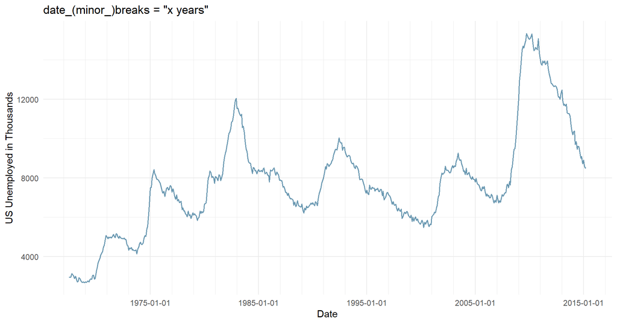

```r
plt_mod3 <- base_plot +
            scale_x_date(date_breaks = "10 years",
                         date_minor_breaks = "2 years") +
            ggtitle("date_(minor_)breaks = \"x years\"")
print(plt_mod3)
```

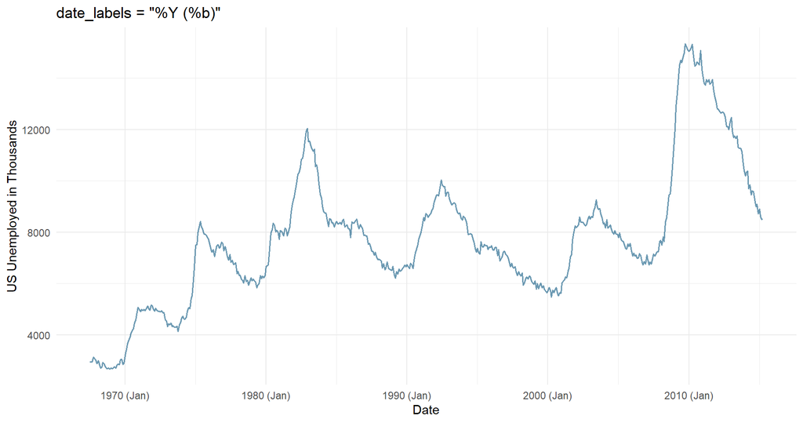

```r
plt_mod4 <- base_plot +
            scale_x_date(date_labels = "%Y (%b)") +
            ggtitle("date_labels = \"%Y (%b)\"")
print(plt_mod4)
```

# 4 Box Plot with different factors

## 4.1 Read and process the data

First we read the data and process into tidy form. See the `tidyData` tip for a detailed explanation.

```r
fi <- here("tidyData/dat/CyclerCPK.csv")
df <- read.csv(fi, header=TRUE)
names(df) <- c("Subject","Age","Gender","TRT",
         "CPK.1", "CPK.2", "CPK.3", "CPK.4")
dfTidy <-  df %>%
           gather(replicate, CPK, CPK.1:CPK.4)

extractReplicate <- function(x){
  unlist(as.integer(unlist(strsplit(x, "[.]"))[2]))
}
test <- unlist(lapply(dfTidy$replicate,extractReplicate))
dfTidy$replicate = as.factor(test)
summary(dfTidy)
```

```
    Subject           Age           Gender              TRT
 Min.   : 1.00   Min.   :18.00   Length:160         Length:160
 1st Qu.:10.75   1st Qu.:22.25   Class :character   Class :character
 Median :20.50   Median :30.50   Mode  :character   Mode  :character
 Mean   :20.50   Mean   :29.20
 3rd Qu.:30.25   3rd Qu.:35.00
 Max.   :40.00   Max.   :40.00
 replicate      CPK
 1:40      Min.   :239.0
 2:40      1st Qu.:367.5
 3:40      Median :503.5
 4:40      Mean   :500.6
           3rd Qu.:623.2
           Max.   :775.0
```

## 4.2 Make the plot

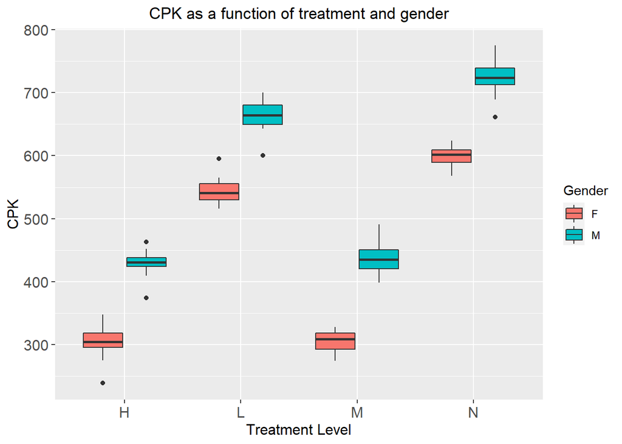

```r
cyclerPlt <- ggplot(dfTidy, aes(x=TRT, y=CPK, fill=Gender)) +
             geom_boxplot() +
             xlab("Treatment Level") +
             ggtitle("CPK as a function of treatment and gender") +
             theme(axis.text=element_text(size=12),
                   axis.title=element_text(size=12),
                   plot.title=element_text(hjust = 0.5)) # center the title...

print(cyclerPlt)
```

# 5 Plot series from different dataframes

Generally, ggplot2 examples show how to plot different series by melting a data frame. This is problematic when our X and Y values are on differen scales. Here is an example from some CASINO data.

## 5.1 Step 1: Load the data

```r
fi <-'./dat/csv/20nm-C-10nm-Ag-On-SiO2-5kV.csv'
df10 <- read.csv(fi, header=TRUE, as.is=TRUE)
panderOptions('table.alignment.default',
               function(df) ifelse(sapply(df, is.numeric), 'right', 'left'))
pander(head(df10))
```

| Z.nm | Hits |
| --- | --- |
| 0 | 0.000655 |
| 0.3627 | 0.000708 |
| 0.7254 | 0.000524 |
| 1.088 | 0.000813 |
| 1.451 | 0.000734 |
| 1.813 | 0.000524 |

## 5.2 Step 2: Make the plot (with a branding caption…)

```r
fi <-'./dat/csv/20nm-C-30nm-Ag-On-SiO2-5kV.csv'
df30 <- read.csv(fi, header=TRUE, as.is=TRUE)
panderOptions('table.alignment.default',
              function(df) ifelse(sapply(df, is.numeric), 'right', 'left'))
pander(head(df30))
```

| Z.nm | Hits |
| --- | --- |
| 0 | 0.000166 |
| 0.2086 | 0.000233 |
| 0.4171 | 0.000116 |
| 0.6257 | 0.000199 |
| 0.8343 | 0.000216 |
| 1.043 | 0.000249 |

Note that these have different X-axis scalings. I will also try to scale the data by the ratio of the BSE coefficients (the data ie reported as **normalized hits** so the sum of the BSE = 1.0). Note how the data series are specified from different dataframes…

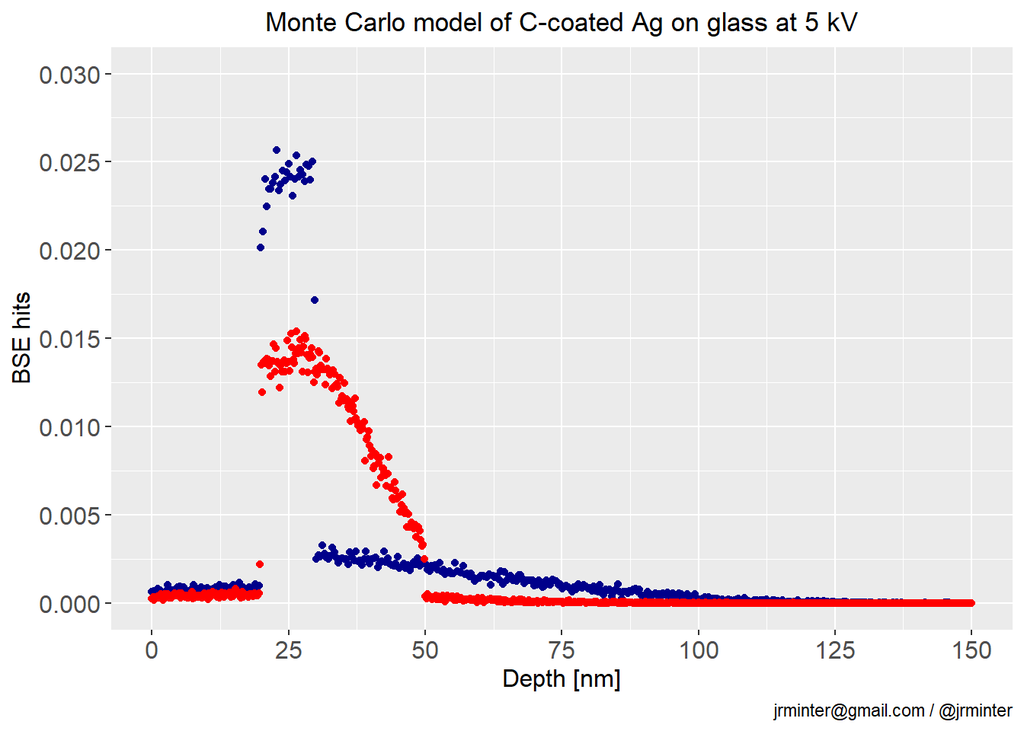

```r
scale = 0.300835/0.190755

plt <-  ggplot() +
        geom_point(data=df10, aes(x=Z.nm, y=Hits),
                   colour="darkblue") +
        geom_point(data=df30, aes(x=Z.nm, y=scale*Hits),
                   colour="red") +
        xlab("Depth [nm]") +
        ylab("BSE hits") +
        scale_x_continuous(breaks = seq(from = 0, to = 150, by = 25),
                           limits = c(0,150)) +
        scale_y_continuous(breaks = seq(from = 0, to = 0.030, by = 0.005),
                           limits = c(0,0.030)) +
        ggtitle("Monte Carlo model of C-coated Ag on glass at 5 kV") +
        labs(caption = 'jrminter@gmail.com / @jrminter') +
        theme(axis.text=element_text(size=12),
              axis.title=element_text(size=12),
              # center the title
              plot.title=element_text(hjust = 0.5)) +
        NULL

print(plt)
```

# 6 Plot/Fit Coulter Data

## 6.1 Set packages and limits

```r
library(ggplot2)
library(pander)

xMaxLim   <- 16
yMaxLim   <- 3000
xPredStep <- 0.02
deltaX    <- 2
deltaY    <- 1000
savPlt    <- FALSE
lSize     <- 1
```

## 6.2 Load data

```r
fi <- './dat/csv/sample-1.csv'
df1 <- read.csv(fi, header = TRUE, as.is=TRUE)
fi <- './dat/csv/sample-2.csv'
df2 <- read.csv(fi, header = TRUE, as.is=TRUE)
```

## 6.3 Fit the Sample 1 data to a Gaussian and calculate a prediction

```r
res1 <- nls(cts ~ k*exp(-1/2*(um-mu)^2/sigma^2),
            start=c(mu=5,sigma=5,k=1000), data = df1)

um <- seq(from=0.0, to=xMaxLim, by=xPredStep)
df1P <- data.frame(um=um)
df1P$cts <- predict(res1, newdat=df1P)
```

## 6.4 Look at the results of the fit

```r
v1 <- summary(res1)$parameters[,"Estimate"]
pander(v1)
```

| mu | sigma | k |
| --- | --- | --- |
| 8.958 | 1.32 | 2794 |

## 6.5 Fit the Sample 2 data to a Gaussian and calculate a prediction

```r
res2 <- nls(cts ~ k*exp(-1/2*(um-mu)^2/sigma^2),
            start=c(mu=5,sigma=5,k=1000), data = df2)

um <- seq(from=0.0, to=xMaxLim, by=xPredStep)
df2P <- data.frame(um=um)
df2P$cts <- predict(res2, newdat=df2P)
```

## 6.6 Look at the results of the fit

```r
v2 <- summary(res2)$parameters[,"Estimate"]
pander(v2)
```

| mu | sigma | k |
| --- | --- | --- |
| 5.294 | 0.8839 | 2123 |

## 6.7 Make a plot

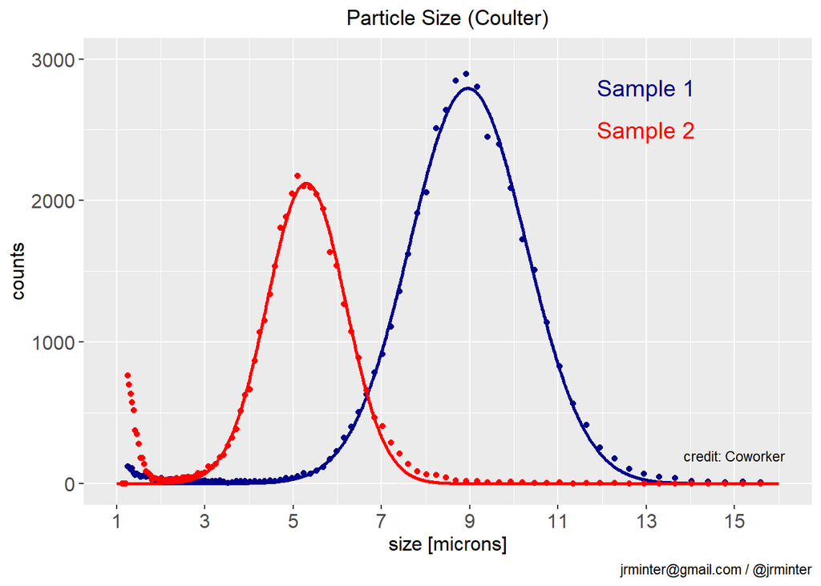

```r
maxCts = max(df1$cts, df2$cts)

plt <-  ggplot() +
        geom_point(data=df1, aes(x=um, y=cts),  colour="darkblue") +
        geom_line(data=df1P, aes(x=um, y=cts),
                  colour='darkblue', size=lSize) +
        geom_point(data=df2, aes(x=um, y=cts),  colour="red") +
        geom_line(data=df2P, aes(x=um, y=cts),
                  colour='red', size=lSize) +
        xlab("size [microns]") +
        ylab("counts") +
        scale_x_continuous(breaks = seq(from = 1, to = xMaxLim, by = deltaX),
                           limits = c(1, xMaxLim)) +
        scale_y_continuous(breaks = seq(from = 0, to = yMaxLim, by = deltaY),
                           limits = c(0, yMaxLim)) +
        ggtitle("Particle Size (Coulter)") +
        annotate("text", label = 'Sample 1', x = 13, y = 2800, size = 5, colour = "darkblue") +
        annotate("text", label = 'Sample 2', x = 13, y = 2500, size = 5, colour = "red") +
        annotate("text", label = 'credit: Coworker', x = 15, y = 200, size = 3, colour = "black") +
        labs(caption = 'jrminter@gmail.com / @jrminter') +
        theme(axis.text=element_text(size=12),
              axis.title=element_text(size=12),
              plot.title=element_text(hjust = 0.5)) # center the title
print(plt)
```

# 7 Plot/fit data from processing EDS spectra

In this case the spectra were simulated using DTSA-II (Ritchie 2011).

## 7.1 Step 1: Load the data

```r
fi <-'./dat/csv/C-ctd-Si-5-kV-10000-Traj.csv'
df <- read.csv(fi, header=TRUE, as.is=TRUE)
panderOptions('table.alignment.default',
              function(df) ifelse(sapply(df, is.numeric), 'right', 'left'))
pander(head(df))
```

| t.C.nm | C.Int.mu | C.Int.unc | Si.Int.mu | Si.Int.unc |
| --- | --- | --- | --- | --- |
| 0 | 32.04 | 1.13 | 5961 | 15.44 |
| 5 | 186.8 | 2.73 | 5746 | 15.16 |
| 10 | 354.8 | 3.77 | 5708 | 15.11 |
| 15 | 507.5 | 5.04 | 5521 | 14.86 |
| 20 | 701.2 | 5.3 | 5458 | 14.78 |
| 25 | 900 | 6 | 5264 | 14.51 |

## 7.2 Compute the C/Si peak ratio and uncertainty

```r
df$c.to.si.mu  <-  df$C.Int.mu / df$Si.Int.mu
df$c.to.si.unc <-  sqrt((df$C.Int.unc/df$C.Int.mu)**2 +
                        (df$Si.Int.unc/df$Si.Int.mu)**2)
```

## 7.3 Make our plot

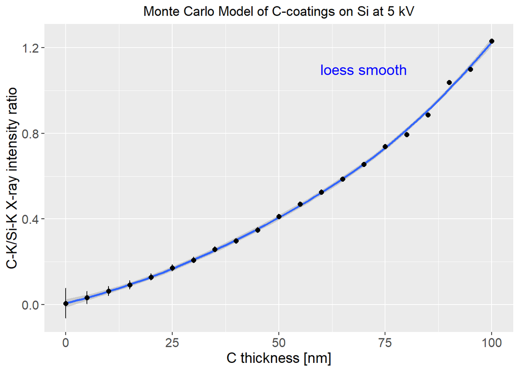

```r
ctosiInt <-  ggplot(df, aes(x=t.C.nm, y=c.to.si.mu)) +
             geom_errorbar(aes(ymin=c.to.si.mu - 1.96*c.to.si.unc,
                           ymax=c.to.si.mu + 1.96*c.to.si.unc), width=.1) +
             stat_smooth(method = "loess") +
             annotate("text", label = 'loess smooth', x = 70, y = 1.1,
                      size = 5, colour = "blue") +
             geom_point(color='black', size=2) +
             xlab("C thickness [nm]") +
             ylab("C-K/Si-K X-ray intensity ratio") +
             ggtitle("Monte Carlo Model of C-coatings on Si at 5 kV") +
             theme(axis.text=element_text(size=12),
                   axis.title=element_text(size=14),
                   plot.title = element_text(hjust = 0.5)) # center the title
print(ctosiInt)
```

## 7.4 Step 2: Compute LOESS interpolated predicted values

```r
t.C.nm <- seq(from=0.5, to=100, by=0.5)
df2P <- data.frame(t.C.nm=t.C.nm, c.to.si.mu=t.C.nm)
df2P$c.to.si.mu <- predict(loess(c.to.si.mu~t.C.nm, data=df2P))
```

## 7.5 Step 3: Write some output

```r
fi <- './dat/pdf/c-ctd-si-series-plt-5kV.pdf'
ggsave(ctosiInt, file=fi, width=9.0, height=6.0, units="in", dpi=300)
fi <- './dat/png/c-ctd-si-series-plt-5kV.png'

# we want the png to be close to 1024x768...
ggsave(ctosiInt, file=fi, width=9.0, height=6.0, units="in", dpi=113.7778)
fi <- './dat/csv/c-ctd-si-loess-pred-5kV.csv'
write.csv(df2, file=fi, row.names=FALSE)
```

# 8 Plotting PhiRhoZ curves from DTSA-II Monte Carlo simulations

DTSA-II computes the PhiRhoZ curves proposed by (Packwood and Brown 1981).

## 8.1 Step 1: Load the data.

```r
library(rEDS)
panderOptions('round', 3)
inDir <- './dat/csv/'
df <- prepDataframeDtsaMcPhiRhoZ(inDir)
pander(head(df))
```

Table continues below

| Z.um | Gen.C.K.L2. | Emit.C.K.L2. | Gen.C.K.L3. | Emit.C.K.L3. | Gen.O.K.L2. |
| --- | --- | --- | --- | --- | --- |
| 0.007 | 0.648 | 0.646 | 0.648 | 0.646 | 0.54 |
| 0.029 | 0 | 0 | 0 | 0 | 1.533 |
| 0.051 | 0 | 0 | 0 | 0 | 1.646 |
| 0.073 | 0 | 0 | 0 | 0 | 1.742 |
| 0.094 | 0 | 0 | 0 | 0 | 1.848 |
| 0.116 | 0 | 0 | 0 | 0 | 1.939 |

Table continues below

| Emit.O.K.L2. | Gen.O.K.L3. | Emit.O.K.L3. | Gen.Si.K.L2. | Emit.Si.K.L2. |
| --- | --- | --- | --- | --- |
| 0.513 | 0.54 | 0.513 | 0.493 | 0.492 |
| 1.416 | 1.533 | 1.416 | 1.37 | 1.359 |
| 1.458 | 1.646 | 1.458 | 1.445 | 1.424 |
| 1.481 | 1.742 | 1.481 | 1.512 | 1.481 |
| 1.507 | 1.848 | 1.507 | 1.586 | 1.542 |
| 1.517 | 1.939 | 1.517 | 1.648 | 1.592 |

Table continues below

| Gen.Si.K.L3. | Emit.Si.K.L3. | Gen.Si.K.M2. | Emit.Si.K.M2. | Gen.Si.K.M3. |
| --- | --- | --- | --- | --- |
| 0.493 | 0.492 | 0.493 | 0.492 | 0.493 |
| 1.37 | 1.359 | 1.37 | 1.361 | 1.37 |
| 1.445 | 1.424 | 1.445 | 1.427 | 1.445 |
| 1.512 | 1.481 | 1.512 | 1.485 | 1.512 |
| 1.586 | 1.542 | 1.586 | 1.548 | 1.586 |
| 1.648 | 1.592 | 1.648 | 1.6 | 1.648 |

Table continues below

| Emit.Si.K.M3. | Gen.Si.L1.M2. | Emit.Si.L1.M2. | Gen.Si.L2.M1. |
| --- | --- | --- | --- |
| 0.492 | 0.575 | 0.496 | 4.657 |
| 1.361 | 1.669 | 0.961 | 13.51 |
| 1.427 | 1.806 | 0.572 | 14.6 |
| 1.485 | 1.945 | 0.338 | 15.73 |
| 1.548 | 2.062 | 0.198 | 16.65 |
| 1.599 | 2.176 | 0.114 | 17.58 |

Table continues below

| Emit.Si.L2.M1. | Gen.Si.L3.M1. | Emit.Si.L3.M1. | Gen_I.C.K.L2. |
| --- | --- | --- | --- |
| 3.894 | 4.777 | 3.995 | 157793 |
| 8.685 | 13.86 | 8.91 | 0 |
| 6.387 | 14.98 | 6.553 | 0 |
| 4.678 | 16.14 | 4.8 | 0 |
| 3.371 | 17.09 | 3.459 | 0 |
| 2.416 | 18.04 | 2.479 | 0 |

Table continues below

| Emit_I.C.K.L2. | Gen_I.C.K.L3. | Emit_I.C.K.L3. | Gen_I.O.K.L2. |
| --- | --- | --- | --- |
| 157118 | 314917 | 313617 | 102673 |
| 0 | 0 | 0 | 291609 |
| 0 | 0 | 0 | 312940 |
| 0 | 0 | 0 | 331357 |
| 0 | 0 | 0 | 351441 |
| 0 | 0 | 0 | 368831 |

Table continues below

| Emit_I.O.K.L2. | Gen_I.O.K.L3. | Emit_I.O.K.L3. | Gen_I.Si.K.L2. |
| --- | --- | --- | --- |
| 97600 | 204534 | 194428 | 64419 |
| 269343 | 580912 | 536555 | 178854 |
| 277286 | 623405 | 552378 | 188654 |
| 281637 | 660094 | 561045 | 197441 |
| 286589 | 700103 | 570912 | 207062 |
| 288496 | 734744 | 574710 | 215196 |

Table continues below

| Emit_I.Si.K.L2. | Gen_I.Si.K.L3. | Emit_I.Si.K.L3. | Gen_I.Si.K.M2. |
| --- | --- | --- | --- |
| 64239 | 127817 | 127461 | 1098 |
| 177527 | 354875 | 352244 | 3049 |
| 185999 | 374321 | 369054 | 3216 |
| 193354 | 391756 | 383647 | 3366 |
| 201423 | 410846 | 399656 | 3530 |
| 207928 | 426986 | 412563 | 3669 |

Table continues below

| Emit_I.Si.K.M2. | Gen_I.Si.K.M3. | Emit_I.Si.K.M3. | Gen_I.Si.L1.M2. |
| --- | --- | --- | --- |
| 1096 | 2179 | 2173 | 536.1 |
| 3029 | 6049 | 6010 | 1555 |
| 3177 | 6381 | 6302 | 1683 |
| 3305 | 6678 | 6557 | 1812 |
| 3447 | 7003 | 6837 | 1921 |
| 3561 | 7278 | 7064 | 2027 |

Table continues below

| Emit_I.Si.L1.M2. | Gen_I.Si.L2.M1. | Emit_I.Si.L2.M1. | Gen_I.Si.L3.M1. |
| --- | --- | --- | --- |
| 461.9 | 3632 | 3037 | 6848 |
| 895.4 | 10535 | 6774 | 19864 |
| 532.9 | 11389 | 4982 | 21475 |
| 315.3 | 12273 | 3649 | 23142 |
| 184 | 12990 | 2629 | 24493 |
| 106.5 | 13710 | 1884 | 25852 |

| Emit_I.Si.L3.M1. |
| --- |
| 5726 |
| 12772 |
| 9394 |
| 6881 |
| 4958 |
| 3553 |

## 8.2 Step 2: Make a dataframe with the transitions we care about.

While we are at it, let’s change the dataframe headers to make it easier to make the plots… We are plotting the generated and emitted X-rays. Let’s make simple mnemonics…

```r
z <- df[,1]
okgen <- df[,8]
okemi  <- df[,9]
sikgen <- df[,12]
sikemi  <- df[,13]

df2 <- data.frame(Z.um=z,
                  O.Gen=okgen, O.Emi=okemi,
                  Si.Gen=sikgen, Si.Emi=sikemi)
pander(head(df2))
```

| Z.um | O.Gen | O.Emi | Si.Gen | Si.Emi |
| --- | --- | --- | --- | --- |
| 0.007 | 0.54 | 0.513 | 0.493 | 0.492 |
| 0.029 | 1.533 | 1.416 | 1.37 | 1.359 |
| 0.051 | 1.646 | 1.458 | 1.445 | 1.424 |
| 0.073 | 1.742 | 1.481 | 1.512 | 1.481 |
| 0.094 | 1.848 | 1.507 | 1.586 | 1.542 |
| 0.116 | 1.939 | 1.517 | 1.648 | 1.592 |

Isn’t that more readable!

In this case we also want to remove the first line because it is the thin C coating that creates a discontinuity. If we remove this first line, the smooth works better…

```r
df3 <- df2[-1, ]
rownames(df3) <- NULL

pander(head(df3))
```

| Z.um | O.Gen | O.Emi | Si.Gen | Si.Emi |
| --- | --- | --- | --- | --- |
| 0.029 | 1.533 | 1.416 | 1.37 | 1.359 |
| 0.051 | 1.646 | 1.458 | 1.445 | 1.424 |
| 0.073 | 1.742 | 1.481 | 1.512 | 1.481 |
| 0.094 | 1.848 | 1.507 | 1.586 | 1.542 |
| 0.116 | 1.939 | 1.517 | 1.648 | 1.592 |
| 0.138 | 2.048 | 1.537 | 1.724 | 1.655 |

## 8.3 Step 3: Plot the Si data.

Note the use of the Unicode in the **xlab** string to create the mu…

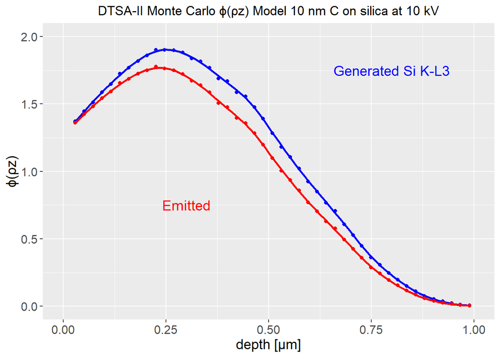

```r
library(ggplot2)

span <- 0.25

plt <-  ggplot(df3, aes(x = Z.um)) +
        geom_point(aes(y = Si.Gen), colour="blue") +
        geom_smooth(aes(x= Z.um, y=Si.Gen), span = span, color = 'blue') +
        annotate("text", label = 'Generated Si K-L3', x = .8, y = 1.75,
                 size = 5, colour = "blue") +
        geom_point(aes(y = Si.Emi), colour="red") +
        geom_smooth(aes(x= Z.um, y=Si.Emi), span = span, color='red') +
        annotate("text", label = 'Emitted', x = .3, y = .75, size = 5,
                 colour = "red") +
        ylab(label="\U03D5(\U03C1z)") + # note the Unicode string for mu
        xlab("depth [\U00B5m]") +
        ggtitle("DTSA-II Monte Carlo \U03D5(\U03C1z) Model 10 nm C on silica at 10 kV") +
        scale_x_continuous(breaks = seq(from = 0, to = 1, by = 0.25), limits = c(0,1)) +
        scale_y_continuous(breaks = seq(from = 0, to = 2, by = 0.5), limits = c(0,2)) +
        theme(axis.text=element_text(size=12),
              axis.title=element_text(size=14),
              plot.title = element_text(hjust = 0.5)) # center the title
print(plt)
```

## 8.4 Step 4: Plot the O data.

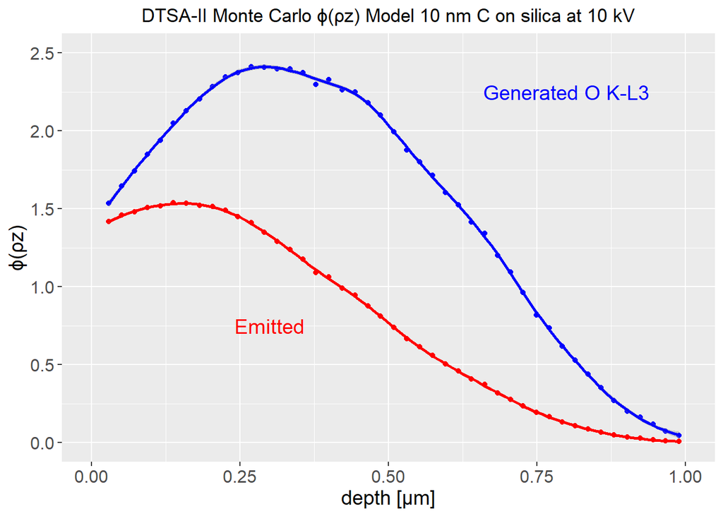

```r
span <- 0.25
df3 <- df2[-1, ]
rownames(df3) <- NULL

plt <-  ggplot(df3, aes(x = Z.um)) +
        geom_point(aes(y = O.Gen), colour="blue") +
        geom_smooth(aes(x= Z.um, y=O.Gen), span = span, color = 'blue') +
        annotate("text", label = 'Generated O K-L3', x = .8, y = 2.25, size = 5, colour = "blue") +
        geom_point(aes(y = O.Emi), colour="red") +
        geom_smooth(aes(x= Z.um, y=O.Emi), span = span, color='red') +
        annotate("text", label = 'Emitted', x = .3, y = .75, size = 5, colour = "red") +
        ylab(label="\U03D5(\U03C1z)") + # note the Unicode string for mu
        xlab("depth [\U00B5m]") +
        ggtitle("DTSA-II Monte Carlo \U03D5(\U03C1z) Model 10 nm C on silica at 10 kV") +
        scale_x_continuous(breaks = seq(from = 0, to = 1, by = 0.25), limits = c(0,1)) +
        scale_y_continuous(breaks = seq(from = 0, to = 2.5, by = 0.5), limits = c(0,2.5)) +
        theme(axis.text=element_text(size=12), axis.title=element_text(size=14),
              plot.title = element_text(hjust = 0.5)) # center the title
print(plt)
```

# 9 Analyze particle size and shape data

## 9.1 Step 1: Load the data

Load the data from a **.csv** file and decide if we want to save plots.

```r
grains <- read.csv("./dat/csv/grains.csv", header = TRUE, as.is=TRUE)
print(names(grains))
```

[1] “img” “part” “ecd.nm” “contrast” “circ” “a.r” “round”  
[8] “solidity”

```r
bSave <- FALSE
```

## 9.2 Step 2: Making a Histogram With ggplot2

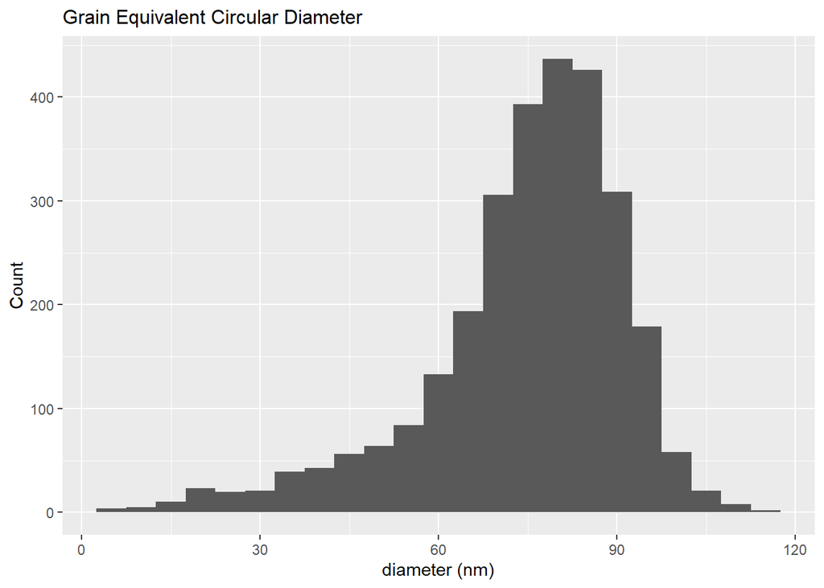

```r
pHD <- ggplot(grains, aes(ecd.nm)) +
       geom_histogram(binwidth = 5) +
       ggtitle("Grain Equivalent Circular Diameter") +
       theme(plot.title = element_text(lineheight=2, size=12)) +
       labs(x="diameter (nm)", y="Count")

if (bSave == TRUE) {
  ggsave("./dat/png/grain-ecd-histo.png", plot=pHistoAgxDiam,
         width=6, height=4, units="in", dpi=150)
}
print(pHD)
```

## 9.3 Step 3: Make a histogram for aspect ratio.

```r
print(summary(grains$a.r))
```

```
##    Min. 1st Qu.  Median    Mean 3rd Qu.    Max.
##   1.001   1.019   1.028   1.240   1.047   5.928
```

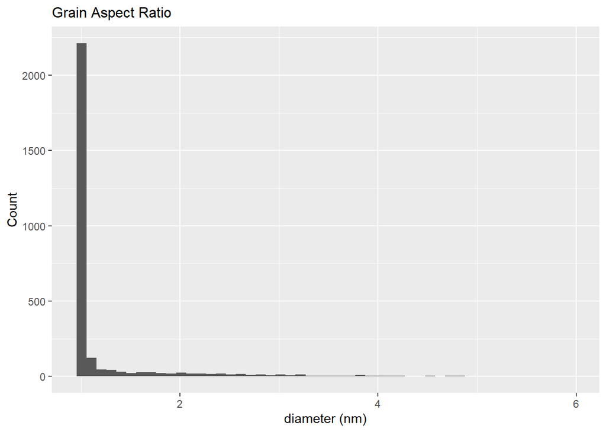

```r
pHAR <-  ggplot(grains, aes(a.r)) +
         geom_histogram(bins=50) +
         ggtitle("Grain Aspect Ratio") +
         theme(plot.title = element_text(lineheight=2, size=12)) +
         labs(x="diameter (nm)", y="Count")
if (bSave == TRUE) {
  ggsave("./dat/png/grain-ecd-histo.png", plot=pHistoAgxAr,
          width=6, height=4, units="in", dpi=150)
}
print(pHAR)
```

## 9.4 Step 4: Make some classes and plot.

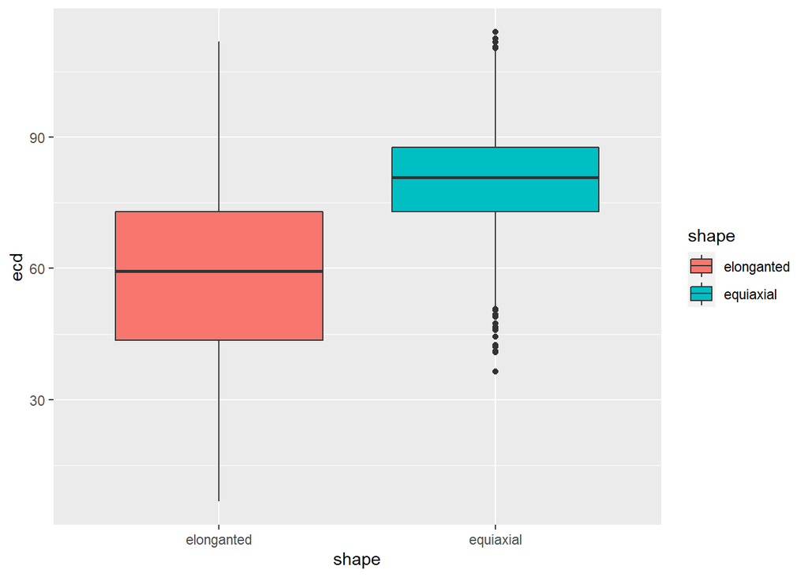

```r
equiAxial <- grains$ecd.nm[grains$a.r < 1.05]
elongated <- grains$ecd.nm[grains$a.r >= 1.05]
df1 <- data.frame(ecd=equiAxial,shape='equiaxial')
df2 <- data.frame(ecd=elongated,shape='elonganted')
shapes <- rbind(df1,df2)
rm(df1, df2)

pBPECDAR <- ggplot(shapes, aes(x=shape, y=ecd)) +
            geom_boxplot(aes(fill = shape)) +
            labs("equivalent circular diameter (nm)")

if (bSave == TRUE) {
  ggsave("./dat/png/grain-ecd-shape-boxplot.png", plot=pBPECDAR,
         width=6, height=4, units="in", dpi=150)
}
print(pBPECDAR)
```

## 9.5 Step 5: Make a scatter plot.

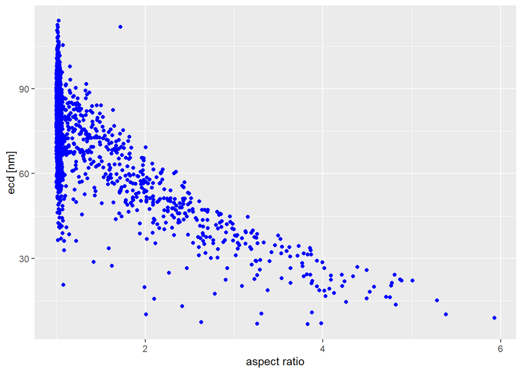

```r
pSPECDAR <- ggplot(grains, aes(x=a.r, y=ecd.nm)) +
            geom_point(colour="blue") +
            labs(x="aspect ratio", y="ecd [nm]")
if (bSave == TRUE) {
  ggsave("./dat/png/grain-ecd-ar.png", plot=pSPECDAR,
         width=6, height=4, units="in", dpi=150)
}
print(pSPECDAR)
```

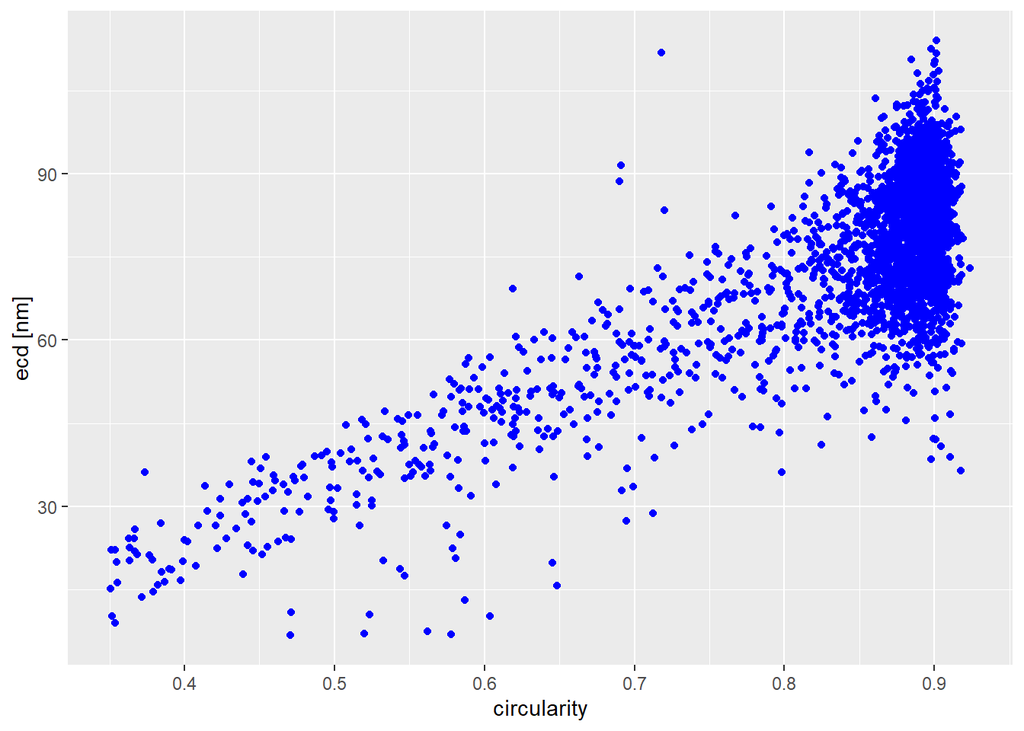

```r
pSPCECD <- ggplot(grains, aes(x=circ, y=ecd.nm)) +
           geom_point(colour="blue") +
           labs(x="circularity", y="ecd [nm]")
if (bSave == TRUE) {
  ggsave("./dat/png/grain-ecd-circ.png", plot=pSPCECD,
         width=6, height=4, units="in", dpi=150)
}
print(pSPCECD)
```

## 9.6 Step 6: Plot the diameter distribution of our dominant morphology.

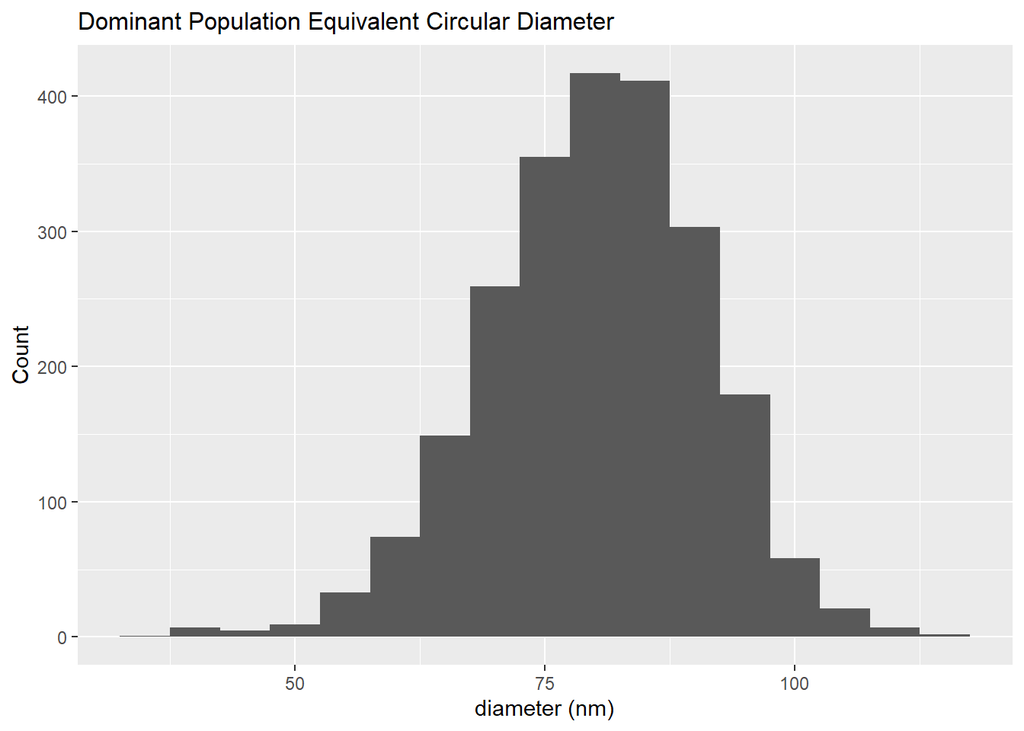

```r
dominant <- grains[grains$a.r <= 1.2, ]
dominant <- dominant[dominant$circ >= 0.8, ]

ecd.mu <- mean(dominant$ecd.nm)
ecd.sd <- sd(dominant$ecd.nm)


pDGD <- ggplot(dominant, aes(ecd.nm)) +
        geom_histogram(binwidth = 5) +
        ggtitle("Dominant Population Equivalent Circular Diameter") +
        theme(plot.title = element_text(lineheight=2, size=12)) +
        labs(x="diameter (nm)", y="Count")

if (bSave == TRUE) {
  ggsave("./dat/png/dom-grain-ecd-histo.png", plot=pDGD,
         width=6, height=4, units="in", dpi=150)
}
print(pDGD)
```

## 9.7 Step 7: Make a plot of computed Gaussian data.

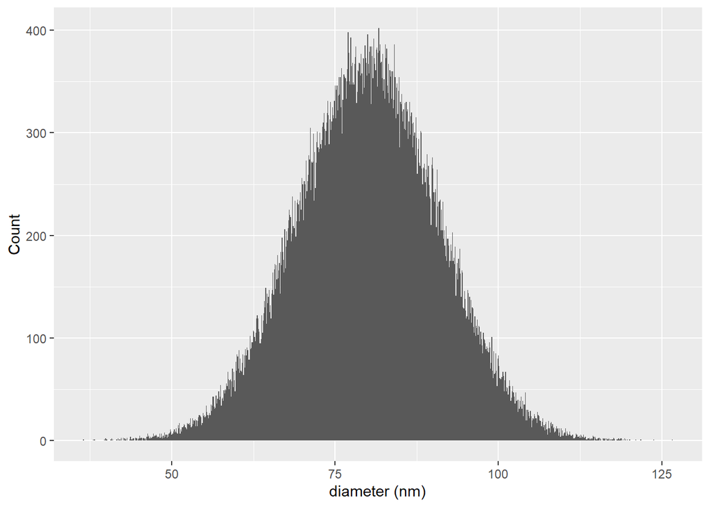

```r
ecd <- rnorm(100000, mean=ecd.mu, sd=ecd.sd)
df <- data.frame(ecd=ecd)
theoHistPlot <- ggplot(df, aes(ecd)) +
                geom_histogram(binwidth = .1) +
                labs(x="diameter (nm)", y="Count")

print(theoHistPlot)
```

Back to Index

## References

Packwood, R. H., and J. D. Brown. 1981. “A Gaussian Expression to Describe Phi(ρz) Curves for Quantitative Electron Probe Microanalysis.” *X-Ray Spectrometry* 10 (3): 138–46. https://doi.org/10.1002/xrs.1300100311.

Ritchie, Nicholas W. M. 2011. “Manipulating Spectra with DTSA-II.” *Microscopy Today* May: 34–39. https://doi.org/10.1017/S1551929511000290.

Wickham, Hadley. 2016. *ggplot2: Elegant Graphics for Data Analysis*. Springer-Verlag New York. https://ggplot2.tidyverse.org.